# Data_analysis

The objectives of this notebook will be to conduct data and statistical analyses on the Bioavailability Master Spreadsheet Clean version 2.

First, set the working directory

```r
setwd("C:/Users/q4q/OneDrive - Oak Ridge National Laboratory/Research/Bioavailability Project/1. Spatial Assessment/Data/Spatial Assessment of Bioavailability Project/5. Statistical data analysis")
```

# Identifying Stream Typologies

## 1. Isolating Flowing Tributaries

To start from here, import the Bioavailability_Master_Spreadsheet_Clean_2.xlsx in the Exploratory Data Analysis folder

```r
library(readxl)

dat <- read_excel("C:/Users/q4q/OneDrive - Oak Ridge National Laboratory/Research/Bioavailability Project/1. Spatial Assessment/Data/Spatial Assessment of Bioavailability Project/4. Exploratory data analysis/Bioavailability_Master_Spreadsheet_Clean_2.xlsx")

head(dat)
```

| Sample_ID | Site | Date | Regime | Flow_state | Network | Relative_elevation_m | Dist_from_EFPC_km | Drainage_area_km2 | Developed_lulc | Type | Development | Distance_from_EFPC | Drainage_area | Orientation | Relative_elevation | pH | Temp_C | DOC_uM | Ca_uM | Mg_uM | Na_uM | K_uM | SO4_uM | Cl_uM | DIC_uM | Zn_uM | Cu_uM | Free_Zn_M | ZnOH_M | … |
| --- | --- | --- | --- | --- | --- | --- | --- | --- | --- | --- | --- | --- | --- | --- | --- | --- | --- | --- | --- | --- | --- | --- | --- | --- | --- | --- | --- | --- | --- | --- |
| WaDE_62 | MTN1.1 | 2023-06-23 | NonPerennial | Flowing | MTN | 3.832 | 0.205 | 1.42 | 63.59 | Tributaries | Medium | <0.22 km | 0.94-11.81 km2 | North slope | 2.1-10.5 m | 7.21 | 16.5 | 75.83 | 1498 | 458.0 | 212 | 37.0 | 38.2 | 174 | 4352 | 0.0360 | 0.002600 | 1.522121e-13 | 4.303651e-16 | … |
| WaDE_63 | EFK13.8 | 2023-06-23 | Perennial | Flowing | EFK | 0.000 | 0.000 | 30.18 | 64.72 | Main Stem | Medium | Main stem | >11.81 km2 | Main stem | 0 m | 8.28 | 18.6 | 160.00 | 1338 | 333.0 | 295 | 54.0 | 139.0 | 172 | 955 | 0.0282 | 0.017400 | 4.059197e-13 | 1.589104e-14 | … |
| WaDE_64 | MTN4 | 2023-06-23 | Perennial | Flowing | MTN | 33.182 | 1.255 | 0.30 | 41.23 | Tributaries | Low | >0.99 km | <0.94 km2 | North slope | >10.5 m | 8.29 | 15.8 | 35.83 | 271 | 182.0 | 90 | 24.8 | 29.7 | 80 | 3223 | 0.1150 | 0.000488 | 5.126304e-13 | 1.648856e-14 | … |
| WaDE_65 | MTN2 | 2023-06-23 | NonPerennial | Pooled | MTN | 12.872 | 0.673 | 0.74 | 54.43 | Tributaries | Medium | 0.22-0.99 km | <0.94 km2 | North slope | >10.5 m | 8.32 | 18.7 | 527.50 | 306 | 75.6 | 7 | 46.4 | 7.5 | 16 | 878 | 0.0707 | 0.035200 | 1.073178e-12 | 4.642505e-14 | … |
| WaDE_66 | MCA3.3 | 2023-06-23 | NonPerennial | Flowing | MCA | 30.455 | 0.995 | 0.16 | 58.52 | Tributaries | Medium | >0.99 km | <0.94 km2 | North slope | >10.5 m | 7.67 | 16.2 | 119.17 | 164 | 79.9 | 88 | 21.2 | 54.3 | 87 | 568 | 0.0316 | 0.000834 | 9.536256e-13 | 7.594370e-15 | … |
| WaDE_67 | MCA3.2 | 2023-06-23 | NonPerennial | Flowing | MCA | 25.535 | 0.939 | 0.22 | 56.61 | Tributaries | Medium | 0.22-0.99 km | <0.94 km2 | North slope | >10.5 m | 7.49 | 16.5 | 81.67 | 46 | 24.7 | 66 | 12.2 | 37.1 | 77 | 286 | 0.0819 | 0.003350 | 5.026322e-12 | 2.707937e-14 | … |

Ensure the structure looks right

```r
str(dat)
```

```
## tibble [386 × 438] (S3: tbl_df/tbl/data.frame)
##  $ Sample_ID                             : chr [1:386] "WaDE_62" "WaDE_63" "WaDE_64" "WaDE_65" ...
##  $ Site                                  : chr [1:386] "MTN1.1" "EFK13.8" "MTN4" "MTN2" ...
##  $ Date                                  : POSIXct[1:386], format: "2023-06-23" "2023-06-23" ...
##  $ Regime                                : chr [1:386] "NonPerennial" "Perennial" "Perennial" "NonPerennial" ...
##  $ Flow_state                            : chr [1:386] "Flowing" "Flowing" "Flowing" "Pooled" ...
##  $ Network                               : chr [1:386] "MTN" "EFK" "MTN" "MTN" ...
##  $ Relative_elevation_m                  : num [1:386] 3.83 0 33.18 12.87 30.45 ...
##  $ Dist_from_EFPC_km                     : num [1:386] 0.205 0 1.255 0.673 0.995 ...
##  $ Drainage_area_km2                     : num [1:386] 1.42 30.18 0.3 0.74 0.16 ...
##  $ Developed_lulc                        : num [1:386] 63.6 64.7 41.2 54.4 58.5 ...
##  $ Type                                  : chr [1:386] "Tributaries" "Main Stem" "Tributaries" "Tributaries" ...
##  $ Development                           : chr [1:386] "Medium" "Medium" "Low" "Medium" ...
##  $ Distance_from_EFPC                    : chr [1:386] "<0.22 km" "Main stem" ">0.99 km" "0.22-0.99 km" ...
##  $ Drainage_area                         : chr [1:386] "0.94-11.81 km2" ">11.81 km2" "<0.94 km2" "<0.94 km2" ...
```

[output cut: 86 more lines]

Since we are only conducting the PCA and cluster analysis on flowing tributaries, we’ll isolate these observations by excluding observations from EFPC main stem and pooled non-perennial sites

```r
library(dplyr)
flowing_tribs<-dat %>%
  filter(Type != "Main Stem", Flow_state != "Pooled")

head(flowing_tribs)
```

| Sample_ID | Site | Date | Regime | Flow_state | Network | Relative_elevation_m | Dist_from_EFPC_km | Drainage_area_km2 | Developed_lulc | Type | Development | Distance_from_EFPC | Drainage_area | Orientation | Relative_elevation | pH | Temp_C | DOC_uM | Ca_uM | Mg_uM | Na_uM | K_uM | SO4_uM | Cl_uM | DIC_uM | Zn_uM | Cu_uM | Free_Zn_M | ZnOH_M | … |
| --- | --- | --- | --- | --- | --- | --- | --- | --- | --- | --- | --- | --- | --- | --- | --- | --- | --- | --- | --- | --- | --- | --- | --- | --- | --- | --- | --- | --- | --- | --- |
| WaDE_62 | MTN1.1 | 2023-06-23 | NonPerennial | Flowing | MTN | 3.832 | 0.205 | 1.42 | 63.59 | Tributaries | Medium | <0.22 km | 0.94-11.81 km2 | North slope | 2.1-10.5 m | 7.21 | 16.5 | 75.83 | 1498 | 458.0 | 212 | 37.0 | 38.2 | 174 | 4352 | 0.036000 | 0.002600 | 1.522121e-13 | 4.303651e-16 | … |
| WaDE_64 | MTN4 | 2023-06-23 | Perennial | Flowing | MTN | 33.182 | 1.255 | 0.30 | 41.23 | Tributaries | Low | >0.99 km | <0.94 km2 | North slope | >10.5 m | 8.29 | 15.8 | 35.83 | 271 | 182.0 | 90 | 24.8 | 29.7 | 80 | 3223 | 0.115000 | 0.000488 | 5.126304e-13 | 1.648856e-14 | … |
| WaDE_66 | MCA3.3 | 2023-06-23 | NonPerennial | Flowing | MCA | 30.455 | 0.995 | 0.16 | 58.52 | Tributaries | Medium | >0.99 km | <0.94 km2 | North slope | >10.5 m | 7.67 | 16.2 | 119.17 | 164 | 79.9 | 88 | 21.2 | 54.3 | 87 | 568 | 0.031600 | 0.000834 | 9.536256e-13 | 7.594370e-15 | … |
| WaDE_67 | MCA3.2 | 2023-06-23 | NonPerennial | Flowing | MCA | 25.535 | 0.939 | 0.22 | 56.61 | Tributaries | Medium | 0.22-0.99 km | <0.94 km2 | North slope | >10.5 m | 7.49 | 16.5 | 81.67 | 46 | 24.7 | 66 | 12.2 | 37.1 | 77 | 286 | 0.081900 | 0.003350 | 5.026322e-12 | 2.707937e-14 | … |
| WaDE_68 | MCA4 | 2023-06-23 | Perennial | Flowing | MCA | 12.175 | 0.680 | 0.70 | 36.47 | Tributaries | Low | 0.22-0.99 km | <0.94 km2 | North slope | >10.5 m | 7.62 | 17.3 | 89.17 | 419 | 172.0 | 95 | 22.5 | 21.8 | 80 | 1253 | 0.000627 | 0.002160 | 8.513883e-15 | 6.588863e-17 | … |
| WaDE_69 | MCA1 | 2023-06-23 | Perennial | Flowing | MCA | 1.555 | 0.047 | 1.51 | 58.93 | Tributaries | Medium | <0.22 km | 0.94-11.81 km2 | North slope | <2.1 m | 7.55 | 16.8 | 94.17 | 1339 | 237.0 | 134 | 28.1 | 38.8 | 93 | 3128 | 0.012900 | 0.007080 | 7.142754e-14 | 4.523851e-16 | … |

Save results to excel

```r
library(openxlsx)

# Create a new workbook for flowing tributary sites
wb <- createWorkbook("Statistical_analyses_flowing_tribs.xlsx")

# Create sheet if it does NOT exist
if(!"Dat" %in% names(wb)) {
  addWorksheet(wb, "Dat")
}

# Write your new table
writeData(wb, "Dat", flowing_tribs)

# Save the workbook (overwrite)
saveWorkbook(wb, "Statistical_analyses_flowing_tribs.xlsx", overwrite = TRUE)
```

## 2. Select Variables

Scaled log-transformed variables

```r
library(dplyr)

# Variables to select
vars_to_select <- c("log_Temp_C_std", "pH_std", "log_DOC_uM_std",
                    "log_DIC_uM_std", "log_Cl_uM_std", "log_Ca_uM_std",
                    "log_Mg_uM_std", "log_SO4_uM_std", "log_Na_uM_std",
                    "log_K_uM_std")

# Subset flowing_tribs
scaled_blm_predict <- flowing_tribs %>%
  dplyr::select(all_of(vars_to_select))

# Peek
head(scaled_blm_predict)
```

| log_Temp_C_std | pH_std | log_DOC_uM_std | log_DIC_uM_std | log_Cl_uM_std | log_Ca_uM_std | log_Mg_uM_std | log_SO4_uM_std | log_Na_uM_std | log_K_uM_std |
| --- | --- | --- | --- | --- | --- | --- | --- | --- | --- |
| 0.2470739 | -0.947274486 | -0.7755931 | 1.0855527 | -0.2639338 | 0.6085213 | 0.2484572 | -0.8109519 | -0.04774051 | -0.1798740 |
| 0.1253110 | 1.564970490 | -1.7554228 | 0.5300362 | -1.0852836 | -2.3347925 | -1.4641431 | -1.0795837 | -1.01279430 | -0.9288322 |
| 0.1955348 | 0.122755781 | -0.1847783 | -2.6809975 | -0.9966176 | -3.1994051 | -2.9918521 | -0.4355878 | -1.03810721 | -1.2224488 |
| 0.2470739 | -0.295951715 | -0.6786271 | -3.9501525 | -1.1256849 | -5.3877813 | -5.1704494 | -0.8421374 | -1.36214579 | -2.2568773 |
| 0.3800599 | 0.006448144 | -0.5638014 | -1.2175376 | -1.0852836 | -1.5846582 | -1.5690155 | -1.4096383 | -0.95189420 | -1.1110355 |
| 0.2976844 | -0.156382549 | -0.4924983 | 0.4746945 | -0.9261222 | 0.4153589 | -0.9741264 | -0.7943180 | -0.56446216 | -0.6949648 |

### a. Normality Checks

```r
# load packages
library(purrr)
library(broom)  # for tidying test outputs

# Shapiro-Wilk test for each variable in scaled_blm_predict
norm_checks_flowing_tribs <- scaled_blm_predict %>%
  map_dfr(~ broom::tidy(shapiro.test(.x)), .id = "variable") %>%
  mutate(normality = ifelse(p.value > 0.05, "Pass", "Fail"))

# View results
norm_checks_flowing_tribs
```

| variable | statistic | p.value | method | normality |
| --- | --- | --- | --- | --- |
| log_Temp_C_std | 0.9107039 | 4.619179e-11 | Shapiro-Wilk normality test | Fail |
| pH_std | 0.9794685 | 1.111092e-03 | Shapiro-Wilk normality test | Fail |
| log_DOC_uM_std | 0.9892446 | 6.002804e-02 | Shapiro-Wilk normality test | Pass |
| log_DIC_uM_std | 0.7399394 | 1.537910e-19 | Shapiro-Wilk normality test | Fail |
| log_Cl_uM_std | 0.9727994 | 1.023154e-04 | Shapiro-Wilk normality test | Fail |
| log_Ca_uM_std | 0.7919513 | 1.497013e-17 | Shapiro-Wilk normality test | Fail |
| log_Mg_uM_std | 0.8397558 | 2.263844e-15 | Shapiro-Wilk normality test | Fail |
| log_SO4_uM_std | 0.9365519 | 6.585421e-09 | Shapiro-Wilk normality test | Fail |
| log_Na_uM_std | 0.9682597 | 2.327153e-05 | Shapiro-Wilk normality test | Fail |
| log_K_uM_std | 0.9817611 | 2.690260e-03 | Shapiro-Wilk normality test | Fail |

Save results to excel

```r
library(openxlsx)

# Load the existing workbook
wb <- loadWorkbook("Statistical_analyses_flowing_tribs.xlsx")

# Create sheet if it does NOT exist
if(!"Norm Checks" %in% names(wb)) {
  addWorksheet(wb, "Norm Checks")
}

# Write your new table
writeData(wb, "Norm Checks", norm_checks_flowing_tribs)

# Save the workbook (overwrite)
saveWorkbook(wb, "Statistical_analyses_flowing_tribs.xlsx", overwrite = TRUE)
```

### b. Residual Plots

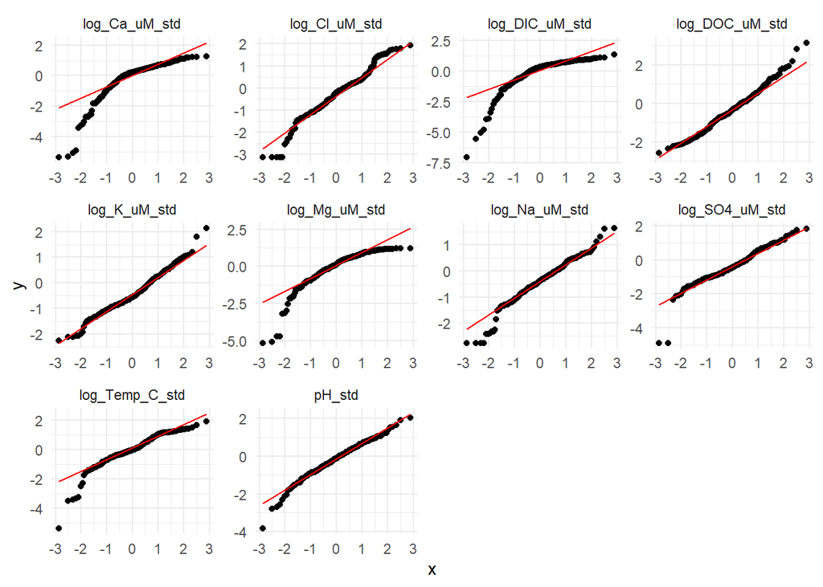

```r
# QQ plots

# Load libraries
library(ggplot2)
library(tidyr)

dr_long <- scaled_blm_predict %>%
  pivot_longer(cols = everything(), names_to = "variable", values_to = "value")

ggplot(dr_long, aes(sample = value)) +
  stat_qq() +
  stat_qq_line(color = "red") +
  facet_wrap(~ variable, scales = "free") +
  theme_minimal()
```

### c. Spearman Correlation Matrix

Most are still not Normally distributed, therefore we’ll perform a Spearman correlation matrix prior to the PCA

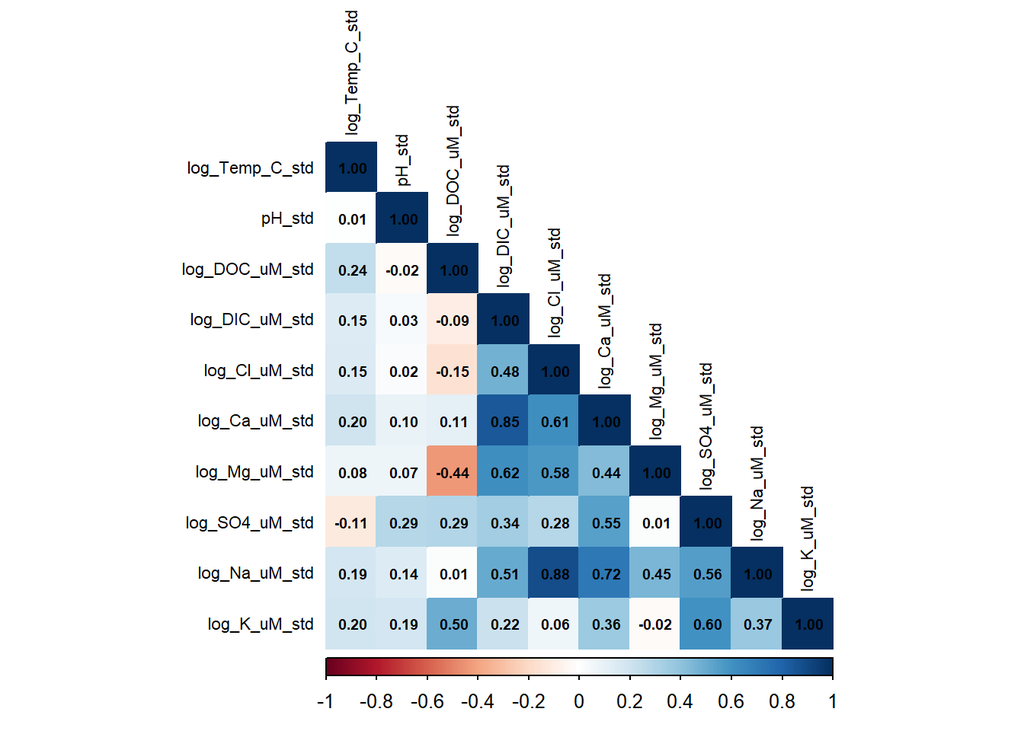

```r
# Spearman correlation matrix on scaled log BLM predictors
cor_matrix_f_tribs <- cor(scaled_blm_predict, method = "spearman")

# Load library
library(corrplot)
# Half heatmap (lower triangle)
corrplot(cor_matrix_f_tribs,
         method = "color",
         type = "lower",         # show only the lower triangle
         tl.cex = 0.7,
         tl.col = "black",
         addCoef.col = "black",
         number.cex = 0.6)
```

Save to excel

```r
library(openxlsx)

# Load the existing workbook
wb <- loadWorkbook("Statistical_analyses_flowing_tribs.xlsx")

# Create the sheet if it doesn't already exist
if(!"Spear Cor" %in% names(wb)) {
  addWorksheet(wb, "Spear Cor")
}

# Write your new table (example: anova_results)
writeData(wb, "Spear Cor", cor_matrix_f_tribs)

# Save the workbook (overwrite)
saveWorkbook(wb, "Statistical_analyses_flowing_tribs.xlsx", overwrite = TRUE)
```

### d. **KMO Adequacy Test**

To determine whether a PCA is appropriate, we’ll conduct a KMO adequacy test on all scaled log BLM predictors. It’s generally accepted that

- KMO > 0.90 is superb
- KMO 0.80-0.90 is great
- KMO 0.70-0.80 is good
- KMO 0.50-0.70 is mediocre
- KMO <0.50 is unaccepatable

```r
library(psych)
# Scaled predictors
KMO(scaled_blm_predict)
```

```
## Kaiser-Meyer-Olkin factor adequacy
## Call: KMO(r = scaled_blm_predict)
## Overall MSA =  0.67
## MSA for each item =
## log_Temp_C_std         pH_std log_DOC_uM_std log_DIC_uM_std  log_Cl_uM_std
##           0.40           0.75           0.43           0.72           0.59
##  log_Ca_uM_std  log_Mg_uM_std log_SO4_uM_std  log_Na_uM_std   log_K_uM_std
##           0.76           0.72           0.74           0.66           0.60
```

The Overall MSA for scaled log-transformed BLM predictors is mediocre.

To see if removing highly correlated predictors can help, we’ll omit DIC and Na:

```r
scaled_blm_predict$log_DIC_uM_std <- NULL
scaled_blm_predict$log_Na_uM_std <- NULL

library(psych)

# Scaled predictors
KMO(scaled_blm_predict)
```

```
## Kaiser-Meyer-Olkin factor adequacy
## Call: KMO(r = scaled_blm_predict)
## Overall MSA =  0.53
## MSA for each item =
## log_Temp_C_std         pH_std log_DOC_uM_std  log_Cl_uM_std  log_Ca_uM_std
##           0.31           0.66           0.46           0.65           0.60
##  log_Mg_uM_std log_SO4_uM_std   log_K_uM_std
##           0.47           0.47           0.63
```